# **Finding the Two Best Markets to Advertise in an E-learning Product**

## **an e-learning company that offers courses on programming.**

Most of our courses are on web and mobile development, but we also cover many other domains, like data science, game development, etc. We want to promote our product and we'd like to invest some money in advertisement. **Our goal in this project is to find out the two best markets to advertise our product in.**

# **Understanding the Data**

To avoid spending money on organizing a survey, we'll first try to make use of existing data to determine whether we can reach any reliable result.

One good candidate for our purpose is freeCodeCamp's 2017 New Coder Survey. freeCodeCamp is a free e-learning platform that offers courses on web development. Because they run a popular Medium publication (over 400,000 followers), their survey attracted new coders with varying interests (not only web development), which is ideal for the purpose of our analysis.

The survey data is publicly available in this GitHub repository. Below, we'll do a quick exploration of the 2017-fCC-New-Coders-Survey-Data.csv file stored in the clean-data folder of the repository we just mentioned. We'll read in the file using the direct link here.

```python
import pandas as pd
direct_link = 'https://raw.githubusercontent.com/freeCodeCamp/2017-new-coder-survey/master/clean-data/2017-fCC-New-Coders-Survey-Data.csv'
fcc = pd.read_csv(direct_link, low_memory = 0) #to silence warning of dtypes
pd.options.display.max_columns = 150 # to avoid truncated output
```

```python
fcc.shape
```

```
(18175, 136)
```

```python
fcc.info()
```

```
<class 'pandas.core.frame.DataFrame'>
RangeIndex: 18175 entries, 0 to 18174
Columns: 136 entries, Age to YouTubeTheNewBoston
dtypes: float64(105), object(31)
memory usage: 18.9+ MB
```

```python
fcc.head(3)
```

|  | Age | AttendedBootcamp | BootcampFinish | BootcampLoanYesNo | BootcampName | BootcampRecommend | ChildrenNumber | CityPopulation | CodeEventConferences | CodeEventDjangoGirls | CodeEventFCC | CodeEventGameJam | CodeEventGirlDev | CodeEventHackathons | CodeEventMeetup | CodeEventNodeSchool | CodeEventNone | CodeEventOther | CodeEventRailsBridge | CodeEventRailsGirls | CodeEventStartUpWknd | CodeEventWkdBootcamps | CodeEventWomenCode | CodeEventWorkshops | CommuteTime | CountryCitizen | CountryLive | EmploymentField | EmploymentFieldOther | … |
| --- | --- | --- | --- | --- | --- | --- | --- | --- | --- | --- | --- | --- | --- | --- | --- | --- | --- | --- | --- | --- | --- | --- | --- | --- | --- | --- | --- | --- | --- | --- |
| 0 | 27.0 | 0.0 | NaN | NaN | NaN | NaN | NaN | more than 1 million | NaN | NaN | NaN | NaN | NaN | NaN | NaN | NaN | NaN | NaN | NaN | NaN | NaN | NaN | NaN | NaN | 15 to 29 minutes | Canada | Canada | software development and IT | NaN | … |
| 1 | 34.0 | 0.0 | NaN | NaN | NaN | NaN | NaN | less than 100,000 | NaN | NaN | NaN | NaN | NaN | NaN | NaN | NaN | NaN | NaN | NaN | NaN | NaN | NaN | NaN | NaN | NaN | United States of America | United States of America | NaN | NaN | … |
| 2 | 21.0 | 0.0 | NaN | NaN | NaN | NaN | NaN | more than 1 million | NaN | NaN | NaN | NaN | NaN | 1.0 | NaN | 1.0 | NaN | NaN | NaN | NaN | NaN | NaN | NaN | NaN | 15 to 29 minutes | United States of America | United States of America | software development and IT | NaN | … |

# **Checking for Sample Representativity¶**

As we mentioned in the introduction, most of our courses are on web and mobile development, but we also cover many other domains, like data science, game development, etc. For the purpose of our analysis, we want to answer questions about a population of new coders that are interested in the subjects we teach. We'd like to know:

- Where are these new coders located.
- What locations have the greatest densities of new coders.
- How much money they're willing to spend on learning.

The JobRoleInterest column describes for every participant the role(s) they'd be interested in working in. If a participant is interested in working in a certain domain, it means that they're also interested in learning about that domain.

```python
fcc.shape
```

```
(18175, 136)
```

```python
# frequency distribution table for JobRoleInterest column into pecentage
fcc['JobRoleInterest'].value_counts(normalize=True)*100
```

```
Full-Stack Web Developer                                                                                                                                                                                                                                                                              11.770…
  Front-End Web Developer                                                                                                                                                                                                                                                                              6.435…
  Data Scientist                                                                                                                                                                                                                                                                                       2.173…
Back-End Web Developer                                                                                                                                                                                                                                                                                 2.030…
  Mobile Developer                                                                                                                                                                                                                                                                                     1.673…
Game Developer                                                                                                                                                                                                                                                                                         1.630…
Information Security                                                                                                                                                                                                                                                                                   1.315…
Full-Stack Web Developer,   Front-End Web Developer                                                                                                                                                                                                                                                    0.915…
  Front-End Web Developer, Full-Stack Web Developer                                                                                                                                                                                                                                                    0.800…
  Product Manager                                                                                                                                                                                                                                                                                      0.786…
Data Engineer                                                                                                                                                                                                                                                                                          0.758…
  User Experience Designer                                                                                                                                                                                                                                                                             0.743…
  User Experience Designer,   Front-End Web Developer                                                                                                                                                                                                                                                  0.614…
  Front-End Web Developer, Back-End Web Developer, Full-Stack Web Developer                                                                                                                                                                                                                            0.557…
Back-End Web Developer, Full-Stack Web Developer,   Front-End Web Developer                                                                                                                                                                                                                            0.514…
  DevOps / SysAdmin                                                                                                                                                                                                                                                                                    0.514…
Back-End Web Developer,   Front-End Web Developer, Full-Stack Web Developer                                                                                                                                                                                                                            0.514…
Full-Stack Web Developer,   Front-End Web Developer, Back-End Web Developer                                                                                                                                                                                                                            0.443…
```

[output cut: 44 more lines]

```python
# splitting the 'JobRoleInterest' column as there are many who have more than one interests
interests_no_nulls = fcc['JobRoleInterest'].dropna() #dropping null values
split_interests = interests_no_nulls.str.split(',')
split_interests
```

```
1                               [Full-Stack Web Developer]
2        [  Front-End Web Developer,  Back-End Web Deve...
3        [  Front-End Web Developer,  Full-Stack Web De...
4        [Full-Stack Web Developer,  Information Securi...
6                               [Full-Stack Web Developer]
9        [Full-Stack Web Developer,    Quality Assuranc...
11       [  DevOps / SysAdmin,    Data Scientist,  Info...
13       [Back-End Web Developer,  Full-Stack Web Devel...
14                              [Full-Stack Web Developer]
15                              [Full-Stack Web Developer]
16                              [Full-Stack Web Developer]
18       [Full-Stack Web Developer,    Front-End Web De...
19       [  Front-End Web Developer,    Mobile Develope...
21                                  [Information Security]
22                              [Full-Stack Web Developer]
```

[output cut: 47 more lines]

```python
# Frequency table for the var describing the number of options
n_of_interests = split_interests.apply(lambda x: len(x)) #x is the list of jobs
n_of_interests.value_counts(normalize=True).sort_index()*100 #frequency table into percentages
```

```
1     31.650458
2     10.883867
3     15.889588
4     15.217391
5     12.042334
6      6.721968
7      3.861556
8      1.759153
9      0.986842
10     0.471968
11     0.185927
12     0.300343
13     0.028604
Name: JobRoleInterest, dtype: float64
```

It turns out that only 31.7% of the participants have a clear idea about what programming niche they'd like to work in, while the vast majority of students have mixed interests. But given that we offer courses on various subjects, the fact that new coders have mixed interest might be actually good for us.

The focus of our courses is on web and mobile development, so let's find out how many respondents chose at least one of these two options.

```python
web_or_mobile = interests_no_nulls.str.contains('Web Developer|Mobile Developer') #returns an array of booleans
frq_table = web_or_mobile.value_counts(normalize = True)*100
frq_table
```

```
True     86.241419
False    13.758581
Name: JobRoleInterest, dtype: float64
```

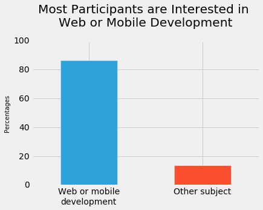

```python
#graph
import matplotlib.pyplot as plt
%matplotlib inline
plt.style.use('fivethirtyeight')

frq_table.plot.bar()
plt.title('Most Participants are Interested in \nWeb or Mobile Development',
          y = 1.08) # y pads the title upward'
plt.ylabel('Percentages', fontsize=10)
plt.xticks([0,1],['Web or mobile\ndevelopment', 'Other subject'],
           rotation = 0) # the initial xtick labels were True and False
plt.ylim([0,100])
plt.show()
```

It turns out that most people in this survey (roughly 86%) are interested in either web or mobile development. These figures offer us a strong reason to consider this sample representative for our population of interest. We want to advertise our courses to people interested in all sorts of programming niches but mostly web and mobile development.

## **New Coders - Locations and Densities**

finding out where these new coders are located, and what are the densities (how many new coders there are) for each location. This should be a good start for finding out the best two markets to run our ads campaign in.

The data set provides information about the location of each participant at a **country level**. We can think of each country as an individual market, so we can frame our goal as finding the two best countries to advertise in.

We can start by examining the frequency distribution table of the CountryLive variable, which describes what country each participant lives in (not their origin country). We'll only consider those participants who answered what role(s) they're interested in, to make sure we work with a representative sample.

```python
#removing those applicants who did not answer their job interests
fcc_good = fcc[fcc['JobRoleInterest'].notnull()].copy()
```

```python
#frequency table with relative and absolute frequencies
absolute_frq = fcc_good['CountryLive'].value_counts(normalize = True)
relative_frq = fcc_good['CountryLive'].value_counts(normalize = True)*100
```

```python
# displaying the frequency table in more readable format
pd.DataFrame(data= {'Absolute Frq': absolute_frq, 'Relative Frq': relative_frq})
```

|  | Absolute Frq | Relative Frq |
| --- | --- | --- |
| United States of America | 0.457005 | 45.700497 |
| India | 0.077216 | 7.721556 |
| United Kingdom | 0.046066 | 4.606610 |
| Canada | 0.038023 | 3.802281 |
| Poland | 0.019158 | 1.915765 |
| Brazil | 0.018865 | 1.886517 |
| Germany | 0.018280 | 1.828020 |
| Australia | 0.016379 | 1.637906 |
| Russia | 0.014917 | 1.491664 |
| Ukraine | 0.013016 | 1.301550 |
| Nigeria | 0.012284 | 1.228429 |
| Spain | 0.011261 | 1.126060 |
| France | 0.010968 | 1.096812 |
| Romania | 0.010383 | 1.038315 |
| Netherlands (Holland, Europe) | 0.009506 | 0.950570 |
| Italy | 0.009067 | 0.906698 |
| Philippines | 0.007605 | 0.760456 |
| Serbia | 0.007605 | 0.760456 |
| Greece | 0.006727 | 0.672711 |
| Ireland | 0.006288 | 0.628839 |
| South Africa | 0.005703 | 0.570342 |
| Mexico | 0.005411 | 0.541094 |
| Turkey | 0.005265 | 0.526470 |
| Hungary | 0.004972 | 0.497221 |
| Singapore | 0.004972 | 0.497221 |
| New Zealand | 0.004826 | 0.482597 |
| Argentina | 0.004680 | 0.467973 |
| Croatia | 0.004680 | 0.467973 |
| Norway | 0.004533 | 0.453349 |
| Indonesia | 0.004533 | 0.453349 |
| ... | ... | ... |
| Somalia | 0.000146 | 0.014624 |
| Sudan | 0.000146 | 0.014624 |
| Channel Islands | 0.000146 | 0.014624 |
| Yemen | 0.000146 | 0.014624 |
| Cameroon | 0.000146 | 0.014624 |
| Trinidad & Tobago | 0.000146 | 0.014624 |
| Guadeloupe | 0.000146 | 0.014624 |
| Rwanda | 0.000146 | 0.014624 |
| Gambia | 0.000146 | 0.014624 |
| Myanmar | 0.000146 | 0.014624 |
| Aruba | 0.000146 | 0.014624 |
| Nambia | 0.000146 | 0.014624 |
| Gibraltar | 0.000146 | 0.014624 |
| Samoa | 0.000146 | 0.014624 |
| Jordan | 0.000146 | 0.014624 |
| Papua New Guinea | 0.000146 | 0.014624 |
| Cayman Islands | 0.000146 | 0.014624 |
| Guatemala | 0.000146 | 0.014624 |
| Angola | 0.000146 | 0.014624 |
| Botswana | 0.000146 | 0.014624 |
| Cuba | 0.000146 | 0.014624 |
| Anguilla | 0.000146 | 0.014624 |
| Qatar | 0.000146 | 0.014624 |
| Bolivia | 0.000146 | 0.014624 |
| Vanuatu | 0.000146 | 0.014624 |
| Turkmenistan | 0.000146 | 0.014624 |
| Nicaragua | 0.000146 | 0.014624 |
| Panama | 0.000146 | 0.014624 |
| Kyrgyzstan | 0.000146 | 0.014624 |
| Liberia | 0.000146 | 0.014624 |

137 rows × 2 columns

45.7% of our potential customers are located in the US, and this definitely seems like the most interesting market. India has the second customer density, but it's just 7.7%, which is not too far from the United Kingdom (4.6%) or Canada (3.8%).

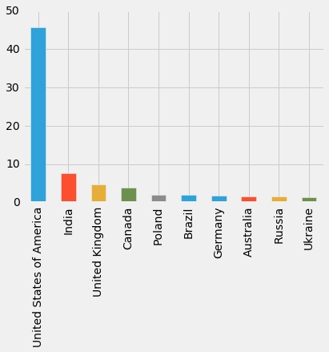

```python
relative_frq.head(10).plot.bar()
```

## **Spending Money for Learning**

The MoneyForLearning column describes in American dollars the amount of money spent by participants from the moment they started coding until the moment they completed the survey. Our company sells subscriptions at a price of \$59 per month, and for this reason we're interested in finding out how much money each student spends per month.

We'll narrow down our analysis to only four countries: the US, India, the United Kingdom, and Canada. We do this for two reasons:

- These are the countries having the highest frequency in the frequency table above, which means we have a decent amount of data for each.
- Our courses are written in English, and English is an official language in all these four countries. The more people know English, the better our chances to target the right people with our ads.

creating a new column that describes the amount of money a student has spent per month so far. To do that, we'll need to divide the MoneyForLearning column to the MonthsProgramming column. The problem is that some students answered that they have been learning to code for 0 months (it might be that they have just started). To avoid dividing by 0, we'll replace 0 with 1 in the MonthsProgramming column.

```python
#replacing 0 with 1
fcc_good['MonthsProgramming'].replace(0,1, inplace=True)
```

```python
#calculating money spent
fcc_good['Money_spent'] = fcc_good['MoneyForLearning'] / fcc_good['MonthsProgramming']
```

```python
fcc_good['Money_spent'].isnull().sum()
```

```
675
```

```python
#keeping those with having values in money_spent column
fcc_good = fcc_good[fcc_good['Money_spent'].notnull()]
```

grouping the data by country, and then measure the average amount of money that students spend per month in each country.

```python
#removing the null values from the CountryLive colummn
fcc_good = fcc_good[fcc_good['CountryLive'].notnull()]
```

```python
fcc_good['CountryLive'].value_counts().head(5)
```

```
United States of America    2933
India                        463
United Kingdom               279
Canada                       240
Poland                       122
Name: CountryLive, dtype: int64
```

```python
#mean amount of money spend by student on each month

countries_mean = fcc_good.groupby('CountryLive').mean()
countries_mean['Money_spent'][['United States of America','India', 'United Kingdom','Canada']]
```

```
CountryLive
United States of America    227.997996
India                       135.100982
United Kingdom               45.534443
Canada                      113.510961
Name: Money_spent, dtype: float64
```

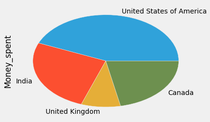

```python
countries_mean['Money_spent'][['United States of America','India', 'United Kingdom','Canada']].plot.pie()
```

The results for the United Kingdom and Canada are a bit surprising relative to the values we see for India. If we considered a few socio-economical metrics (like GDP per capita), we'd intuitively expect people in the UK and Canada to spend more on learning than people in India.

It might be that we don't have have enough representative data for the United Kingdom and Canada, or we have some outliers (maybe coming from wrong survey answers) making the mean too large for India, or too low for the UK and Canada. Or it might be that the results are correct.

```python
#keeping the countries of our interests
only_4 = fcc_good[fcc_good['CountryLive'].str.contains(
    'United States of America|India|United Kingdom|Canada')]
```

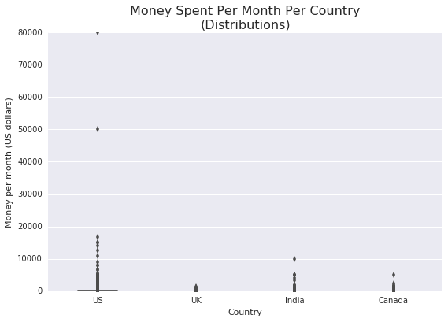

```python
#creating boxplot
import seaborn as sns
sns.boxplot(y = 'Money_spent', x = 'CountryLive',
            data = only_4)
plt.title('Money Spent Per Month Per Country\n(Distributions)',
         fontsize = 16)
plt.ylabel('Money per month (US dollars)')
plt.xlabel('Country')
plt.xticks(range(4), ['US', 'UK', 'India', 'Canada']) # avoids tick labels overlap
plt.show()
```

It's hard to see on the plot above if there's anything wrong with the data for the United Kingdom, India, or Canada, but we can see immediately that there's something really off for the US: two persons spend each month \$50000 or more for learning. This is not impossible, but it seems extremely unlikely, so we'll remove every value that goes over \$20,000 per month.

```python
#keeping those having values less than 20000
fcc_good = fcc_good[fcc_good['Money_spent'] < 20000]
```

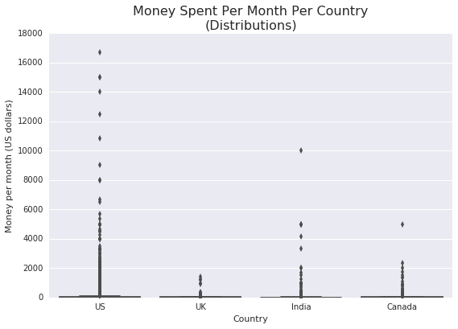

```python
#recomputing the boxplot
#keeping the countries of our interests
only_4 = fcc_good[fcc_good['CountryLive'].str.contains(
    'United States of America|India|United Kingdom|Canada')]
#creating boxplot
import seaborn as sns
sns.boxplot(y = 'Money_spent', x = 'CountryLive',
            data = only_4)
plt.title('Money Spent Per Month Per Country\n(Distributions)',
         fontsize = 16)
plt.ylabel('Money per month (US dollars)')
plt.xlabel('Country')
plt.xticks(range(4), ['US', 'UK', 'India', 'Canada']) # avoids tick labels overlap
plt.show()
```

```python
# Inspect the extreme outliers for India
india_outliers = only_4[(only_4['CountryLive'] == 'India') & (only_4['Money_spent'] >= 2500)]
india_outliers
```

|  | Age | AttendedBootcamp | BootcampFinish | BootcampLoanYesNo | BootcampName | BootcampRecommend | ChildrenNumber | CityPopulation | CodeEventConferences | CodeEventDjangoGirls | CodeEventFCC | CodeEventGameJam | CodeEventGirlDev | CodeEventHackathons | CodeEventMeetup | CodeEventNodeSchool | CodeEventNone | CodeEventOther | CodeEventRailsBridge | CodeEventRailsGirls | CodeEventStartUpWknd | CodeEventWkdBootcamps | CodeEventWomenCode | CodeEventWorkshops | CommuteTime | CountryCitizen | CountryLive | EmploymentField | EmploymentFieldOther | … |
| --- | --- | --- | --- | --- | --- | --- | --- | --- | --- | --- | --- | --- | --- | --- | --- | --- | --- | --- | --- | --- | --- | --- | --- | --- | --- | --- | --- | --- | --- | --- |
| 1728 | 24.0 | 0.0 | NaN | NaN | NaN | NaN | NaN | between 100,000 and 1 million | NaN | NaN | NaN | 1.0 | NaN | NaN | NaN | NaN | NaN | NaN | NaN | NaN | NaN | NaN | NaN | NaN | NaN | India | India | NaN | NaN | … |
| 1755 | 20.0 | 0.0 | NaN | NaN | NaN | NaN | NaN | more than 1 million | NaN | NaN | 1.0 | NaN | NaN | 1.0 | 1.0 | NaN | NaN | NaN | NaN | NaN | NaN | NaN | NaN | NaN | NaN | India | India | NaN | NaN | … |
| 7989 | 28.0 | 0.0 | NaN | NaN | NaN | NaN | NaN | between 100,000 and 1 million | 1.0 | NaN | NaN | NaN | NaN | NaN | NaN | NaN | NaN | NaN | NaN | NaN | NaN | NaN | NaN | 1.0 | 15 to 29 minutes | India | India | software development and IT | NaN | … |
| 8126 | 22.0 | 0.0 | NaN | NaN | NaN | NaN | NaN | more than 1 million | NaN | NaN | NaN | 1.0 | NaN | 1.0 | NaN | NaN | NaN | NaN | NaN | NaN | NaN | NaN | NaN | NaN | NaN | India | India | NaN | NaN | … |
| 13398 | 19.0 | 0.0 | NaN | NaN | NaN | NaN | NaN | more than 1 million | NaN | NaN | NaN | NaN | NaN | NaN | NaN | NaN | 1.0 | NaN | NaN | NaN | NaN | NaN | NaN | NaN | NaN | India | India | NaN | NaN | … |
| 15587 | 27.0 | 0.0 | NaN | NaN | NaN | NaN | NaN | more than 1 million | NaN | NaN | NaN | NaN | NaN | 1.0 | NaN | NaN | NaN | NaN | NaN | NaN | NaN | NaN | NaN | NaN | 15 to 29 minutes | India | India | software development and IT | NaN | … |

```python
#removing outliers ffrom India
only_4 = only_4.drop(india_outliers.index) #using the row table
```

```python
#examing the outlieers for USA
usa_outliers = only_4[(only_4['CountryLive'] == 'United States of America') & (only_4['Money_spent'] >= 6000)]
usa_outliers
```

|  | Age | AttendedBootcamp | BootcampFinish | BootcampLoanYesNo | BootcampName | BootcampRecommend | ChildrenNumber | CityPopulation | CodeEventConferences | CodeEventDjangoGirls | CodeEventFCC | CodeEventGameJam | CodeEventGirlDev | CodeEventHackathons | CodeEventMeetup | CodeEventNodeSchool | CodeEventNone | CodeEventOther | CodeEventRailsBridge | CodeEventRailsGirls | CodeEventStartUpWknd | CodeEventWkdBootcamps | CodeEventWomenCode | CodeEventWorkshops | CommuteTime | CountryCitizen | CountryLive | EmploymentField | EmploymentFieldOther | … |
| --- | --- | --- | --- | --- | --- | --- | --- | --- | --- | --- | --- | --- | --- | --- | --- | --- | --- | --- | --- | --- | --- | --- | --- | --- | --- | --- | --- | --- | --- | --- |
| 718 | 26.0 | 1.0 | 0.0 | 0.0 | The Coding Boot Camp at UCLA Extension | 1.0 | NaN | more than 1 million | 1.0 | NaN | NaN | NaN | NaN | NaN | NaN | NaN | NaN | NaN | NaN | NaN | NaN | NaN | NaN | NaN | 15 to 29 minutes | United States of America | United States of America | architecture or physical engineering | NaN | … |
| 1222 | 32.0 | 1.0 | 0.0 | 0.0 | The Iron Yard | 1.0 | NaN | between 100,000 and 1 million | NaN | NaN | NaN | NaN | NaN | NaN | 1.0 | NaN | NaN | NaN | NaN | NaN | NaN | NaN | NaN | NaN | NaN | United States of America | United States of America | NaN | NaN | … |
| 3184 | 34.0 | 1.0 | 1.0 | 0.0 | We Can Code IT | 1.0 | NaN | more than 1 million | NaN | NaN | NaN | NaN | NaN | NaN | 1.0 | NaN | NaN | NaN | NaN | NaN | NaN | NaN | NaN | NaN | Less than 15 minutes | NaN | United States of America | software development and IT | NaN | … |
| 3930 | 31.0 | 0.0 | NaN | NaN | NaN | NaN | NaN | between 100,000 and 1 million | NaN | NaN | NaN | NaN | NaN | NaN | NaN | NaN | NaN | NaN | NaN | NaN | NaN | NaN | NaN | NaN | NaN | United States of America | United States of America | NaN | NaN | … |
| 6805 | 46.0 | 1.0 | 1.0 | 1.0 | Sabio.la | 0.0 | NaN | between 100,000 and 1 million | NaN | NaN | NaN | NaN | NaN | NaN | NaN | NaN | NaN | NaN | NaN | NaN | NaN | NaN | NaN | NaN | NaN | United States of America | United States of America | NaN | NaN | … |
| 7198 | 32.0 | 0.0 | NaN | NaN | NaN | NaN | NaN | more than 1 million | 1.0 | NaN | NaN | NaN | NaN | NaN | 1.0 | NaN | NaN | NaN | NaN | NaN | NaN | NaN | NaN | NaN | 15 to 29 minutes | United States of America | United States of America | education | NaN | … |
| 7505 | 26.0 | 1.0 | 0.0 | 1.0 | Codeup | 0.0 | NaN | more than 1 million | NaN | NaN | NaN | NaN | NaN | NaN | NaN | NaN | NaN | NaN | NaN | NaN | 1.0 | NaN | NaN | NaN | NaN | United States of America | United States of America | NaN | NaN | … |
| 9778 | 33.0 | 1.0 | 0.0 | 1.0 | Grand Circus | 1.0 | NaN | between 100,000 and 1 million | NaN | NaN | NaN | NaN | NaN | NaN | 1.0 | NaN | NaN | NaN | NaN | NaN | NaN | NaN | NaN | NaN | 15 to 29 minutes | United States of America | United States of America | education | NaN | … |
| 16650 | 29.0 | 0.0 | NaN | NaN | NaN | NaN | 2.0 | more than 1 million | NaN | NaN | NaN | NaN | NaN | NaN | 1.0 | NaN | NaN | NaN | NaN | NaN | NaN | NaN | NaN | NaN | NaN | United States of America | United States of America | NaN | NaN | … |
| 16997 | 27.0 | 0.0 | NaN | NaN | NaN | NaN | 1.0 | more than 1 million | NaN | NaN | NaN | NaN | NaN | NaN | NaN | NaN | NaN | NaN | NaN | NaN | NaN | NaN | NaN | NaN | 15 to 29 minutes | United States of America | United States of America | health care | NaN | … |
| 17231 | 50.0 | 0.0 | NaN | NaN | NaN | NaN | 2.0 | less than 100,000 | NaN | NaN | NaN | NaN | NaN | NaN | NaN | NaN | NaN | NaN | NaN | NaN | NaN | NaN | 1.0 | NaN | NaN | Kenya | United States of America | NaN | NaN | … |

Out of these 11 extreme outliers, six people attended bootcamps, which justify the large sums of money spent on learning. For the other five, it's hard to figure out from the data where they could have spent that much money on learning. Consequently, we'll remove those rows where participants reported thay they spend \$6000 each month, but they have never attended a bootcamp.

Also, the data shows that eight respondents had been programming for no more than three months when they completed the survey. They most likely paid a large sum of money for a bootcamp that was going to last for several months, so the amount of money spent per month is unrealistic and should be significantly lower (because they probably didn't spend anything for the next couple of months after the survey). As a consequence, we'll remove every these eight outliers.

```python
#remving respondents who did not attend bootcamp
usa_outliers = only_4[(only_4['CountryLive'] == 'United States of America') &
                      (only_4['Money_spent'] >= 6000) &
                      (only_4['AttendedBootcamp'] == 0)]
only_4 = only_4.drop(usa_outliers.index)
```

```python
#removing students who had been programming for less than 3 months
us_outliers = only_4[(only_4['CountryLive'] == 'United States of America') &
                    (only_4['Money_spent'] >= 6000) &
                    (only_4['MonthsProgramming'] <= 3)]
only_4 = only_4.drop(us_outliers.index)
```

```python
# Examine the extreme outliers for Canada
canada_outliers = only_4[
    (only_4['CountryLive'] == 'Canada') &
    (only_4['Money_spent'] > 4500)]

canada_outliers
```

|  | Age | AttendedBootcamp | BootcampFinish | BootcampLoanYesNo | BootcampName | BootcampRecommend | ChildrenNumber | CityPopulation | CodeEventConferences | CodeEventDjangoGirls | CodeEventFCC | CodeEventGameJam | CodeEventGirlDev | CodeEventHackathons | CodeEventMeetup | CodeEventNodeSchool | CodeEventNone | CodeEventOther | CodeEventRailsBridge | CodeEventRailsGirls | CodeEventStartUpWknd | CodeEventWkdBootcamps | CodeEventWomenCode | CodeEventWorkshops | CommuteTime | CountryCitizen | CountryLive | EmploymentField | EmploymentFieldOther | … |
| --- | --- | --- | --- | --- | --- | --- | --- | --- | --- | --- | --- | --- | --- | --- | --- | --- | --- | --- | --- | --- | --- | --- | --- | --- | --- | --- | --- | --- | --- | --- |
| 13659 | 24.0 | 1.0 | 0.0 | 0.0 | Bloc.io | 1.0 | NaN | more than 1 million | 1.0 | NaN | 1.0 | NaN | NaN | NaN | 1.0 | NaN | NaN | NaN | NaN | NaN | NaN | NaN | NaN | 1.0 | 30 to 44 minutes | Canada | Canada | finance | NaN | … |

Here, the situation is similar to some of the US respondents — this participant had been programming for no more than two months when he completed the survey. He seems to have paid a large sum of money in the beginning to enroll in a bootcamp, and then he probably didn't spend anything for the next couple of months after the survey. We'll take the same approach here as for the US and remove this outlier.

```python
# Remove the extreme outliers for Canada
only_4 = only_4.drop(canada_outliers.index)
```

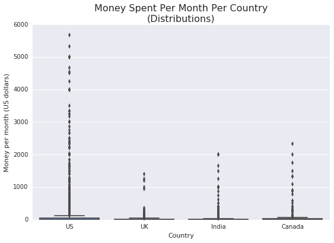

```python
# recomputing mean values and generating boxplots
sns.boxplot(y = 'Money_spent', x = 'CountryLive',
            data = only_4)
plt.title('Money Spent Per Month Per Country\n(Distributions)',
         fontsize = 16)
plt.ylabel('Money per month (US dollars)')
plt.xlabel('Country')
plt.xticks(range(4), ['US', 'UK', 'India', 'Canada']) # avoids tick labels overlap
plt.show()
```

## **Choosing the Two Best Markets**

The data suggests strongly that we shouldn't advertise in the UK, but let's take a second look at India before deciding to choose Canada as our second best choice:

```python
#frequency table
only_4['CountryLive'].value_counts(normalize = True)*100
```

```
United States of America    74.967908
India                       11.732991
United Kingdom               7.163030
Canada                       6.136072
Name: CountryLive, dtype: float64
```

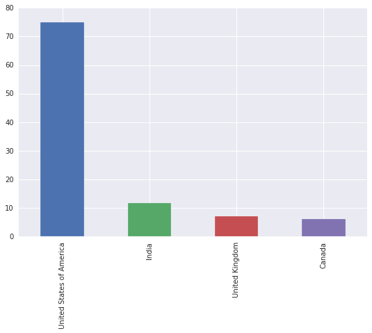

```python
(only_4['CountryLive'].value_counts(normalize = True)*100).plot.bar()
```

So it's not crystal clear what to choose between Canada and India. Although it seems more tempting to choose Canada, there are good chances that India might actually be a better choice because of the large number of potential customers.

At this point, it seems that we have several options:

- Advertise in the US, India, and Canada by splitting the advertisement budget in various * combinations:
  1. 60% for the US, 25% for India, 15% for Canada.
  2. 50% for the US, 30% for India, 20% for Canada; etc.
- Advertise only in the US and India, or the US and Canada. Again, it makes sense to split the advertisement budget unequally. For instance:
  1. 70% for the US, and 30% for India.
  2. 65% for the US, and 35% for Canada; etc.
- Advertise only in the US.

At this point, it's probably best to send our analysis to the marketing team and let them use their domain knowledge to decide. They might want to do some extra surveys in India and Canada and then get back to us for analyzing the new survey data.

# **Conclusion**

In this project, we analyzed survey data from new coders to find the best two markets to advertise in. The only solid conclusion we reached is that the US would be a good market to advertise in.

For the second best market, it wasn't clear-cut what to choose between India and Canada. We decided to send the results to the marketing team so they can use their domain knowledge to take the best decision.